# Markov Discrete Problems

## Markov Chains

A worker’s employment dynamics obey the stochastic matrix

$$P = \begin{bmatrix}
1-\alpha & \alpha \\
\beta & 1-\beta
\end{bmatrix}$$

with $\alpha\in(0,1)$ and $\beta\in (0,1)$. First line corresponds to employment, second line to unemployment.

**Which is the stationary equilibrium?**

We want a solution to $(P-I)\mu' = 0$ but $P-I$ is not invertible `rank(P)=1` (since all the rows sum to 1). We need to add the condition $sum(\mu)=1$. We can replace a column of P-I by ones, without losing any information.

$$M = \begin{pmatrix} 1 & \alpha \\ 1 & 0-\beta \end{pmatrix}$$

Stationary equilibrium $\mu=(x, y)$ satisfies $\mu'M=(1,0)$

Some algebra to get: $x=\frac{\beta}{\alpha+\beta}$ and $y=\frac{\alpha}{\alpha+\beta}$

```
α = β = 0.1
```

```
0.1
```

```
P = [1-α α ; β 1-β]
```

```
using LinearAlgebra # import I
```

```
M = P - I
```

```
M[:,1] .= 1.0
```

```
μ_0 = M' \ [1,0]
```

**In the long run, what will the the fraction $p$ of time spent unemployed? (Denote by $X_m$ the fraction of dates were one is unemployed)**

$X_m = (\sum_{m\geq 0} 1_{E_t(2) > 0})/(m+1)$

**Illustrate this convergence by generating a simulated series of length 10000 starting at $X_0=1$. Plot $X_m-p$ against $m$. (Take $\alpha=\beta=0.1$).**

```
cat = [Categorical(P[i,:]) for i=1:2]
```

```
function cumulative_time(;x_0=1, T=10000)
    cumul = []
    count = 0
    cat = [Categorical(P[i,:]) for i=1:2]
    for t=1:T
        #draw according to distribution conditional on x_0
        if x_0 == 2
            count += 1
        end
        push!(cumul, count/(length(cumul)+1))
        x_1 = rand(cat[x_0])
        x_0 = x_1

    end
    return cumul
end
```

```
c_1 = cumulative_time(;x_0=1, T=100000) ;
c_2 = cumulative_time(;x_0=2, T=100000) ;
```

```
using Plots
```

```
y = α/(α + β)
```

[output not shown]

## Mine management (from Compecon)

A mine operator must decide how much ore to extract from a mine that will be shut down after $T$ years of operation.

The price of extracted ore is $p$ dollars per ton in any year, and the total cost of extaction given that the mine contains $s$ tons at the beginning of the year is $c(s,x)$ dollars.

The mine currently contains $s_0$ tons of ore. Assuming the amount of ore extracted in any year must be an integer number of tons, what extraction schedule maximizes profits?

Calibration: $p=1$, initial stock $\overline{s}=100$, cost of extraction $c(s,x)=\frac{x^2}{1+s}$ and annual discount factor $\delta=0.9$.

**Define kind of problem, the state space, the actions, the reward function, and the Bellman updating equation**

- kind of problem:

```
- maximize profits: revenue - cost
- discrete state/discrete action
- finite horizon problem
```

- state-space: $(s, T-t)$
- action: $x\in[0,s]$
- reward: $r(s,x) = p x - c(s,x)$
- objective: $V(s_0) = \sum_{t=0}^{T} \delta^t r(s_t, x_t)$
- Bellman: $V(s, T-t) = \max_{x \in [0,s]} \left[ r(s,x) + \delta V(s-x, T-t-1) \right]$

**Solve the problem with the more adequate method**

```
p = 1
s0 = 100
c(s,x) = x^2/(1+s)
r(s,x) = p*x - c(s,x)
δ = 0.9
```

```
0.9
```

```
# you can end up with s=0, 1, ... s0
# in all states, the continuation value is 0
V_T = zeros(s0+1);
```

```
V_T1 = zeros(s0+1); # just to initialize
for s in 0:(s0)
#     for x in (0:s)
#         # value of choosing x in state s
#         v_x = r(s,x) + δ * V_T[1+s-x]
#     end
    v_s = maximum( [r(s,x) + δ * V_T[1+s-x] for x in (0:s)] )
    V_T1[1+s] = v_s
end
```

```
using PyPlot
```

```
plot(V_T1)
ylim(0,100)
```

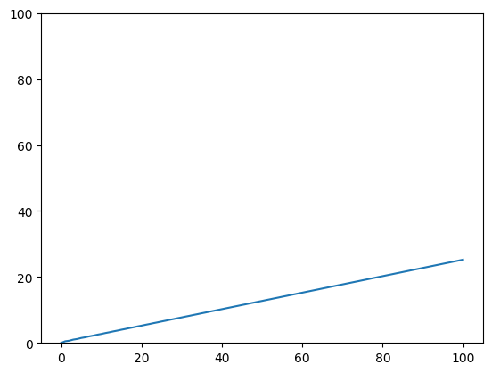

```
(0, 100)
```

```
function update(V_t)
    V_t_m1 = zeros(s0+1); # just to initialize
    for s in 0:(s0)
    #     for x in (0:s)
    #         # value of choosing x in state s
    #         v_x = r(s,x) + δ * V_T[1+s-x]
    #     end
        v_s = maximum( [r(s,x) + δ * V_t[1+s-x] for x in (0:s)] )
        V_t_m1[1+s] = v_s
    end
    return V_t_m1
end
```

```
update (generic function with 1 method)
```

```
T = 20
values = [V_T]
for t=1:T
    push!(values, update(values[end]))
end
```

```
for v in values
    plot(v)
end
```

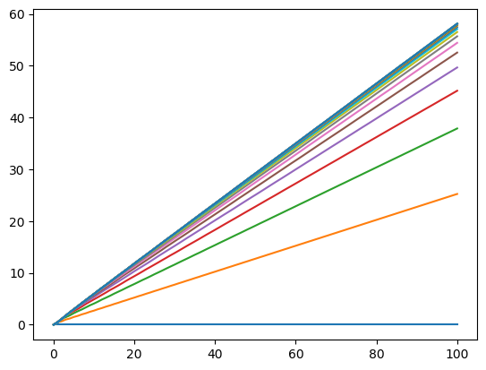

```
# now we need to rewrite the update function to keep the decision rule
findmax([0.0, 0.1])
```

```
(0.1, 2)
```

```
zeros(Int64, 2)
```

```
2-element Array{Int64,1}:
 0
 0
```

```
function update_2(V_t)
    V_t_m1 = zeros(s0+1); # just to initialize
    π_t_m1 = zeros(Int64, s0+1); # just to initialize
    for s in 0:(s0)
    #     for x in (0:s)
    #         # value of choosing x in state s
    #         v_x = r(s,x) + δ * V_T[1+s-x]
    #     end
        v_s, i_s = findmax( [r(s,x) + δ * V_t[1+s-x] for x in (0:s)] )
        V_t_m1[1+s] = v_s
        π_t_m1[1+s] = i_s-1
    end
    return V_t_m1, π_t_m1
end
```

```
update_2 (generic function with 1 method)
```

```
T = 20
values = [V_T]
policies = []
for t=1:T
    val, pol = update_2(values[end])
    push!(values, val)
    push!(policies, pol)
end
```

```
subplot(121)
for (i,v) in enumerate(values)
    plot(v, label=string(T-i))
end
legend(loc="upper left")
subplot(122)
for p in policies
    plot(p)
end
```

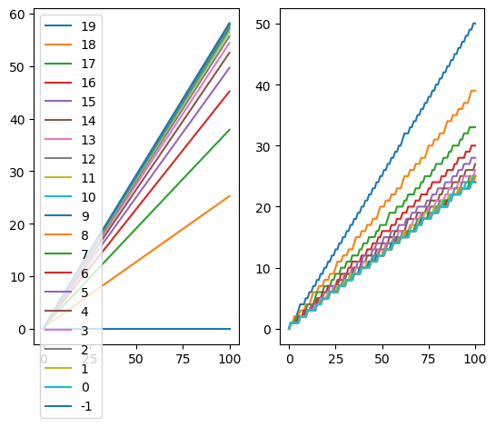

```
function simulate(s0, T)
    sim = []
    s = s0
    for t=0:T-1
        x = policies[end-t][s]
        push!(sim, x)
        s = s - x
    end
    return sim
end
```

```
simulate (generic function with 1 method)
```

```
sim = simulate(100, 20)
```

```
20-element Array{Any,1}:
 24
 18
 14
 10
  8
  6
  5
  3
  3
  2
  2
  1
  1
  1
  1
  0
  0
  0
  0
  0
```

```
plot(sim)
```

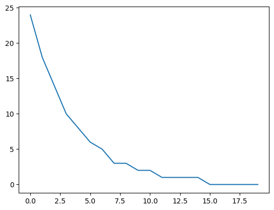

```
1-element Array{PyCall.PyObject,1}:
 PyObject <matplotlib.lines.Line2D object at 0x7f44200c3d50>
```

## Asset replacement (from Compecon)

At the beginning of each year, a manufacturer must decide whether to continue to operate an aging physical asset or replace it with a new one.

An asset that is $a$ years old yields a profit contribution $p(a)$ up to $n$ years, at which point, the asset becomes unsafe and must be replaced by law.

The cost of a new asset is $c$. What replacement policy maximizes profits?

Calibration: profit $p(a)=50-2.5a-2.5a^2$. Maximum asset age: 5 years. Asset replacement cost: 75, annual discount factor $\delta=0.9$.

**Define kind of problem, the state space, the actions, the reward function, and the Bellman updating equation**

**Solve the problem using Value Function Iteration**

**Solve the problem using Policy Iteration. Compare with VFI.**

## Water management (Compecon)

Water from a reservoir can be used for either irrigation or recreation. Irrigatoin during the spring benefits farmers but reduces the reservoir level during the summer, damaging the interests of recreational users.

Specifically, if the reservoir contains $s$ units of water at the beginning of the year and $x$ units are released for irrigation, farmer and recreational user benefits during the year will be $F(x)$ and $U(s-x)$, respectively.

Reservoir levels are replenished by random rainfall during the winter. Specifically, it rains $k$ units with probability $p_k$ for$k=0,1,2, ...K$. The reservoir can hold only $M$ units of water, and excess rainfall flows out without benefit to either farmer or recreational user.

What irrigation policy maximizes the sum of farmer and recreational user benfefits over an infinite time horizon?

Calibration: $F(x)=\alpha_1 x^{\beta_1}$, $G(x)=\alpha_2 (s-x)^{\beta_2}$ where $\alpha_1=14$, $\beta_1=0.8$, $\alpha_2=10$ and $\beta_2=0.4$. Reservoir capacity: $M=30$ and discount factor $\delta=0.9$. Probabilities that it rains 0,1,2,3,4 units: 0.1, 0.2, 0.4, 0.2 and 0.1.

**Define kind of problem, the state space, the actions, the reward function, and the Bellman updating equation**

**Solve the problem**

### Brock-Mirman Stochastic Growth model

This is a neoclassical growth model with unpredictable shocks on productivity.

Social planner tries to solve:

$$\max E_t \left[ \sum_{n=0}^{\infty} \beta^n \log C_{t+n} \right]$$

s.t.

$$K_{t+1} = Y_t - C_t$$
$$Y_{t+1} = A_{t+1}K_{t+1}^\alpha$$

**What are the states? What are the controls? Is it possible to bound them in a natural way? Propose a discretization scheme.**

- states: $A_t$, $K_t$ - actions: $C_t \in [0, Y_t]$ - decision rule: $C^h(K)$ and $C^l(K)$

- state: $N$ regularly spaced points between $K_{min}$ and $K_{max}$

First order conditions:

$$\frac{1}{C_t} = \beta E_t \left[ \frac{1}{C_{t+1}} A_{t+1} \alpha K_{t+1}^{\alpha-1} \right]$$

Steady_states if $A$ stays permanently at $A^i$:

$C = Y-K = A^i K^{\alpha} - K $

Steady-state $K$ is pinned down by :

$$\frac{1}{ A^i K^{\alpha} - K} = \beta \frac{1}{ A^i K^{\alpha} - K} A^i \alpha K^{\alpha-1}$$

```
α = 0.3 # labour share
β = 0.96   ## 1/rf
Ah = 1.05
Al = 0.95
K_max = (1/(β*α*Ah))^(1/(α-1))+0.05
K_min = (1/(β*α*Al))^(1/(α-1))-0.05

N = 100

K_grid = range(K_min, K_max; length=N)     # linspace
```

```
0.10699294375094563:0.0012538405454583653:0.2311231577513238
```

Bellman:

$V(A, K) = \max_{C(A,K)} \log C(A,K) + \beta E_t V(A', K')$

Bellman update: given a guess $V_n$, define $V_{n+1}$

$V_{n+1}(A, K) = \max_{C(A,K)} \log C(A,K) + \beta E_t V_n(A', K')$

```
V0 = [zeros(N), zeros(N)] # low state, high state
```

```
2-element Array{Array{Float64,1},1}:
 [0.0, 0.0, 0.0, 0.0, 0.0, 0.0, 0.0, 0.0, 0.0, 0.0  …  0.0, 0.0, 0.0, 0.0, 0.0, 0.0, 0.0, 0.0, 0.0, 0.0]
 [0.0, 0.0, 0.0, 0.0, 0.0, 0.0, 0.0, 0.0, 0.0, 0.0  …  0.0, 0.0, 0.0, 0.0, 0.0, 0.0, 0.0, 0.0, 0.0, 0.0]
```

```
A = [0.95, 1.05]
Π = [0.9 0.1; 0.1 0.9]
```

```
2×2 Array{Float64,2}:
 0.9  0.1
 0.1  0.9
```

```
function Bellman_step_0(V0)
    V = deepcopy(V0)
    for i=1:2
        for (n,k) in enumerate(K_grid)
            nn0 = -1
            gv = -Inf
            for (nn,kk) in enumerate(K_grid)
                y = A[i]*k^α
                c = y - kk
                eV = Π[i,1] * V0[1][nn] +  Π[i, 2]*V0[2][nn]
                v = log(c) + β * eV
                if v > gv
                    gv = v
                    nn0 = nn
                end
            end
            V[i][n] = gv
        end
    end
    return V
end
```

```
Bellman_step_0 (generic function with 1 method)
```

```
max(0,2)
```

```
2
```

```
T = 100
values = [V0]
ϵ_0 = 1.0
for t=1:T
    VV = values[end]
    VVV = Bellman_step_0(VV)
    D = VVV-VV
    ϵ = max( maximum(u->abs(u), D[1]) ,  maximum(u->abs(u), D[2]) )
    println("SA: \t", ϵ, "\tSA/SA(-1): ", ϵ/ϵ_0)
    ϵ_0 = ϵ
    push!(values, VVV)
end
```

```
SA:    0.9705138055528969  SA/SA(-1): 0.9705138055528969
SA:     0.9109975655763257  SA/SA(-1): 0.9386755349217675
SA:     0.8586498354347234  SA/SA(-1): 0.9425380131411377
SA:     0.8139300937521758  SA/SA(-1): 0.9479185346143967
SA:     0.7742699457297864  SA/SA(-1): 0.951273274785113
SA:     0.7381413002621686  SA/SA(-1): 0.9533384374960276
SA:     0.7047402570525625  SA/SA(-1): 0.9547497976366545
SA:     0.6735992699317093  SA/SA(-1): 0.9558121069298718
SA:     0.6444011417627298  SA/SA(-1): 0.9566535632202516
SA:     0.6168911592843846  SA/SA(-1): 0.957309227598367
SA:     0.5908870349425728  SA/SA(-1): 0.9578464953656046
SA:     0.5662312836892482  SA/SA(-1): 0.9582733250261266
SA:     0.5427984628583076  SA/SA(-1): 0.9586161670929493
SA:     0.520484744306847   SA/SA(-1): 0.9588913379858164
SA:     0.49920318746606007 SA/SA(-1): 0.9591120449281784
SA:     0.47888011565880184 SA/SA(-1): 0.9592889782807327
SA:     0.45945231380342655 SA/SA(-1): 0.9594307610190742
SA:     0.44086486657940327 SA/SA(-1): 0.959544338627543
SA:     0.4230694875282204  SA/SA(-1): 0.9596352977971362
SA:     0.40602322561709947 SA/SA(-1): 0.959708127355831
SA:     0.38968746210154315 SA/SA(-1): 0.9597664308717113
SA:     0.37402713072849103 SA/SA(-1): 0.9598130992241896
SA:     0.3590101098406073  SA/SA(-1): 0.959850450263768
SA:     0.34460674686106607 SA/SA(-1): 0.9598803415705033
SA:     0.3307894847926409  SA/SA(-1): 0.9599042613231371
SA:     0.3175325673959559  SA/SA(-1): 0.9599234014195003
SA:     0.3048118051122941  SA/SA(-1): 0.9599387162457598
SA:     0.29260438794435295 SA/SA(-1): 0.9599509698666563
SA:     0.2808887346946509  SA/SA(-1): 0.959960773889932
SA:     0.269644370408745   SA/SA(-1): 0.959968617829656
SA:     0.2588518257506376  SA/SA(-1): 0.9599748934429918
SA:     0.24849255348214427 SA/SA(-1): 0.9599799142291049
SA:     0.23854885832771444 SA/SA(-1): 0.9599839310470752
SA:     0.22900383735897734 SA/SA(-1): 0.9599871446224894
SA:     0.21984132868845307 SA/SA(-1): 0.9599897155602617
SA:     0.21104586676561965 SA/SA(-1): 0.9599917723600649
SA:     0.2026026429555685  SA/SA(-1): 0.9599934178316418
SA:     0.19449747037826626 SA/SA(-1): 0.9599947342292087
SA:     0.18671675221536432 SA/SA(-1): 0.959995787360269
SA:     0.17924745286765997 SA/SA(-1): 0.9599966298734189
```

[output cut: 45 more lines]

```
SA:     0.027410920150963136    SA/SA(-1): 0.9599999998826124
SA:     0.026314483342350314    SA/SA(-1): 0.959999999906085
SA:     0.02526190400667616 SA/SA(-1): 0.9599999999247509
SA:     0.024251427844887985    SA/SA(-1): 0.9599999999397856
SA:     0.023281370729925754    SA/SA(-1): 0.959999999951891
SA:     0.022350115899833156    SA/SA(-1): 0.9599999999615328
SA:     0.021456111263148614    SA/SA(-1): 0.9599999999690733
SA:     0.0205978668120963  SA/SA(-1): 0.9599999999754676
SA:     0.01977395213921085 SA/SA(-1): 0.9599999999805029
SA:     0.01898299405332793 SA/SA(-1): 0.9599999999840959
SA:     0.018223674290954506    SA/SA(-1): 0.959999999987341
SA:     0.017494727319135706    SA/SA(-1): 0.9599999999900887
SA:     0.01679493822623357 SA/SA(-1): 0.9599999999921858
SA:     0.016123140697075655    SA/SA(-1): 0.9599999999935355
SA:     0.015478215069105516    SA/SA(-1): 0.9599999999945971
```

It looks like the series converges at a geometric rate. Successive approximation arror decrease monotonically. From looking at the the right column, we get confirmation decay is geometric with rate 0.96, which is exactly what the theory tells us.

Let's look at the value function:

```
using Plots
pl = plot(K_grid, values[end][1],label="Bad State")
plot!(pl, K_grid, values[end][2], label="Good State")
xlabel!(pl, "\$K_t\$")
ylabel!(pl, "\$V_t\$")
```

[figure not shown]

Now it would be nice, if we had kept the policy function too (investment as a function of capital). Let's rewrite the `Bellman_step` function to add the policy. We'll also redefine it as an inplace function for performance reasons. By convention first arguments are the ones being modified, hence we reorder the function arguments.

```
"""
Bellman_step!(V, P, V0)

# Arguments
- `V::Array{Vector{Flaot64}}`: Updated value function (\$V_{t}\$)
- `P::Array{Vector{Flaot64}}`: Updated policy (\$P_{t}\$)
- `V0::Array{Vector{Flaot64}}`: Initial guess for value function (\$V_{t+1}\$)
...
"""
function Bellman_step!(V, P, V0)

    for i=1:2
        for (n,k) in enumerate(K_grid)
            nn0 = -1
            gv = -100000.0
            kopt = -1.0
            for (nn,kk) in enumerate(K_grid)
                y = A[i]*k^α
                c = y - kk
                eV = Π[i,1] * V0[1][nn] +  Π[i, 2]*V0[2][nn]
                v = log(c) + β * eV
                if v > gv
                    gv = v
                    nn0 = nn
                    kopt = kk
                end
            end
            P[i][n] = kopt
            V[i][n] = gv
        end
    end
    return V
end
```

```
Bellman_step!
```

```
distance(A::Vector{Float64}, B::Vector{Float64}) = maximum( (u)->abs(u[1]-u[2]), zip(A[1],B[1]))
distance(A::Vector{Vector{Float64}}, B::Vector{Vector{Float64}}) = maximum(u->distance(u[1],u[2]),zip(A,B))
```

```
distance (generic function with 2 methods)
```

```
function FixedPoint(V0; T=1000, tol_η=1e-6, verbose=true, keep_history=false)
     # let's allocate the memory once for all
    V0 = deepcopy(V0)
    V = deepcopy(V0)
    P = deepcopy(V0)
    D =
    η_0 = 1.0::Float64
    for t=1:T
        Bellman_step!(V, P, V0)
        η = distance(V,V0)
        if verbose
            println("SA: \t", η, "\tSA/SA(-1): ", η/η_0)
        end
        η_0 = η
        V0[1][:] .= V[1]
        V0[2][:] .= V[2]
        if η<tol_η
            break
        end
    end
    return V0, P
end
```

```
FixedPoint (generic function with 1 method)
```

```
@time V, P= FixedPoint(V0, verbose=false)
```

```
  3.630278 seconds (122.34 M allocations: 2.256 GiB, 9.25% gc time)
```

```
([[-22.368343931569044, -22.36343254814532, -22.358577534115966, -22.353784458187512, -22.349037813997086, -22.34434746074303, -22.339714105347113, -22.3351218532696, -22.330585041467486, -22.326091215608233  …  -22.064912914993343, -22.062518719927755, -22.060133464200014, -22.05776254627267, -22.0…
```

```
pl_v = plot(K_grid, V[1], label="bad")
plot!(pl_v, K_grid, V[2], label="good")
xlabel!(pl_v,"\$K_t\$")
ylabel!(pl_v,"\$V_t\$")

pl = plot(K_grid, P[1], label="")
plot!(pl, K_grid, P[2], label="")
plot!(pl, K_grid, K_grid, color="black", label="")
xlabel!(pl,"\$K_t\$")
ylabel!(pl,"\$K_{t+1}\$")

plot(pl, pl_v)
```

[figure not shown]

The right hand side shows the value of holding a given amount of capital. This value reflects its value for production today, as well as for being reinvested tomorrow, assuming this is done in the optimal way.

Obviously, having more capital increases value. Also higher productivity ("good" state) also increases the value of capital since it is able to produce more, both today and in the future.

The left hand side graph shows the amount of capital invested for next period. When productivity of capital is high, more capital is invested (logical!) than when productivity is low. We can see that it capital converges towards two different states, in bad times and in good times. If we were to simulate the model (which we don't do here), we would observe that the economy would eventually fluctuate between these two states.

**Propose some ideas to improve performances.**

The code above was written in a naive way but might be very suboptimal.

Let's try to improve its performance. First, execution time: we call the function twice, once alone, once with a @time macro, to be sure, it is already compiled when we set the timer

```
V, P= FixedPoint(V0, verbose=false)
@time V, P= FixedPoint(V0, verbose=false)
```

```
  3.120111 seconds (121.66 M allocations: 2.222 GiB, 10.75% gc time)
```

```
([[-22.368343931569044, -22.36343254814532, -22.358577534115966, -22.353784458187512, -22.349037813997086, -22.34434746074303, -22.339714105347113, -22.3351218532696, -22.330585041467486, -22.326091215608233  …  -22.064912914993343, -22.062518719927755, -22.060133464200014, -22.05776254627267, -22.0…
```

If we have some experience with this kind of models, we know 3 seconds is very slow. Also the amount of memory allocated for the program (all the intermediary variables and arrays) is very big: 2 Gb is gigantic compared to our state space that has just 100 points, especially since we are doing inplace operations and shouldn't be allocating anything.

Here checking the Julia performance trick would be a good idea. But suppose we don't know where to start. Let's try to use libary Traceur to get some suggestions. (it takes a lot of time though so you might want to skip that part if you are running it on your laptop).

```
using Traceur
```

```
V0_, V1_, P_ = [deepcopy(V0) for i=1:3]
@trace Bellman_step!(V1_, P_, V0_)
```

```
┌ Warning: getindex returns Union{Float64, Int64}
└ @ tuple.jl:24
┌ Warning: n is assigned as Union{Nothing, Tuple{Float64,Int64}}
└ @ iterators.jl:139
┌ Warning:  is assigned as Tuple{Int64,Int64}
└ @ math.jl:124
┌ Warning:  is assigned as Nothing
└ @ math.jl:125
┌ Warning: n is assigned as Union{Nothing, Tuple{Float64,Int64}}
└ @ iterators.jl:139
```

[output not shown]

The solution is very simple: suppress dependencey on global variables by passing them as arguments to the functions. There are many options for doing so: - one argument per parameter - a dictionary with all parameters - define a special structure with all that defines a model The latter option, provides the best performance, but involves the definition of a new type. Instead, we opt for a dictionary of parameters.

```
"""
Bellman_step!(V, P, V0)

# Arguments
- `V::Array{Vector{Flaot64}}`: Updated value function (\$V_{t}\$)
- `P::Array{Vector{Flaot64}}`: Updated policy (\$P_{t}\$)
- `V0::Array{Vector{Flaot64}}`: Initial guess for value function (\$V_{t+1}\$)
- `K_grid`: Grid for capital values.
- `p::Dict{:Symbol, Float64}`: Dictionary of parameters
...
"""
function Bellman_step!(V, P, V0, A, Π, K_grid, p::Dict{Symbol, Float64})

    α = p[:α]
    β = p[:β]


    for i=1:2
        for (n,k) in enumerate(K_grid)
            nn0 = -1
            gv = -100000.0
            kopt = -1.0
            for (nn,kk) in enumerate(K_grid)
                y = A[i]*k^α
                c = y - kk
                eV = Π[i,1] * V0[1][nn] +  Π[i, 2]*V0[2][nn]
                v = log(c) + β * eV
                if v > gv
                    gv = v
                    nn0 = nn
                    kopt = kk
                end
            end
            P[i][n] = kopt
            V[i][n] = gv
        end
    end
end
```

```
Bellman_step!
```

```
p = Dict{Symbol,Float64}()
p[:α] = 0.3 # labour share
p[:β] = 0.96   ## 1/rf
Ah = 1.05
Al = 0.95
K_max = (1/(β*α*Ah))^(1/(α-1))+0.05
K_min = (1/(β*α*Al))^(1/(α-1))-0.05

N = 100
K_grid = range(K_min, K_max; length=N)     # linspace

A = [0.95, 1.05]
Π = [0.9 0.1; 0.1 0.9]
```

```
2×2 Array{Float64,2}:
 0.9  0.1
 0.1  0.9
```

```
# let's see how our new Bellman_update version compares
V0 = [collect(K_grid)*0 for i=1:2]
P0 = deepcopy(V0)
V1 = deepcopy(V0)
@time Bellman_step!(V1, P0, V0, A, Π, K_grid, p::Dict{Symbol, Float64});
```

```
  0.089173 seconds (58.84 k allocations: 2.933 MiB)
```

Let's update the FixedPoint function to reflect the new arguments of `Bellman_update`.

```
typeof(K_grid)
```

```
StepRangeLen{Float64,Base.TwicePrecision{Float64},Base.TwicePrecision{Float64}}
```

```
function FixedPoint(V0, A, Π, grid_K, p; T=1000, tol_η=1e-6, verbose=true, keep_history=false, out=nothing)
     # let's allocate the memory once for all

    if typeof(out) <: Nothing
        V0 = deepcopy(V0)
        V = deepcopy(V0)
        P = deepcopy(V0)
    else
        V0,V,P = out
    end

    η_0 = 1.0::Float64

    for t=1:T

        Bellman_step!(V, P, V0,  A, Π, grid_K, p)

        η = distance(V,V0)
        if verbose
            println("SA: \t", η, "\tSA/SA(-1): ", η/η_0)
        end

        V0[1][:] .= V[1]
        V0[2][:] .= V[2]

        if η<tol_η
            break
        end

        η_0 = η

    end

    return V0, P
end
```

```
FixedPoint (generic function with 2 methods)
```

```
FixedPoint(V0, A, Π, K_grid, p; verbose=false)
@time FixedPoint(V0, A, Π, K_grid,  p; verbose=false)
```

```
  0.110033 seconds (2.04 k allocations: 64.578 KiB)
```

```
([[-22.368343775590464, -22.363432392166736, -22.358577378137383, -22.35378430220893, -22.349037658018506, -22.34434730476445, -22.33971394936853, -22.33512169729102, -22.330584885488904, -22.32609105962965  …  -22.06491275901476, -22.062518563949173, -22.060133308221435, -22.05776239029409, -22.055…
```

```
# we pass
V0 = [collect(K_grid)*0 for i=1:2]
P0 = deepcopy(V0)
V1 = deepcopy(V0)
out = (V1, P0, V0)
@time FixedPoint(V0, A, Π, K_grid, p; verbose=false, out=out)
```

```
  0.142634 seconds (2.02 k allocations: 58.016 KiB)
```

```
([[-22.368343931569044, -22.36343254814532, -22.358577534115966, -22.353784458187512, -22.349037813997086, -22.34434746074303, -22.339714105347113, -22.3351218532696, -22.330585041467486, -22.326091215608233  …  -22.064912914993343, -22.062518719927755, -22.060133464200014, -22.05776254627267, -22.0…
```

Note: the remaining allocations are due to the function `distance`, which allocates a Float64 for its output.

**Policy iteration**

We have already computed the improvement function.